# Version comparison: Program-Area score equivalence

- Show All Code
- Hide All Code
- View Source

Parameterized v7 ↔︎ v8 (or any two versions) composite-score delta report

Published

2026-08-28

> **Not a pipeline stage** — a standalone, parameterized *report* (no `msens:` target block, so `tar_make()` never runs it). Render it on demand for any two release versions whose `sdm.duckdb` are on disk. The reusable comparison **core lives in `msens`** (`score_delta`, `score_delta_summary`, `assert_within_tolerance`, `pra_score_delta`) so this notebook only *orchestrates* — the math is unit-tested in `msens/tests/testthat/test-validate.R` and can’t drift from what’s reported here.

> ```r
> # render with version suffixes in the output filename (see scripts/render_validate.R):
> source("scripts/render_validate.R"); render_versions("v7", "v8")   # -> _output/validate_v7_v8.html
> # or directly:
> quarto render validate_versions.qmd -P version_a:v7 -P version_b:v8 --output validate_v7_v8.html
> ```

> **Scope note:** the `nc` / `gm` **density** surfaces are *not* folded into either version’s scores (v8 built with `MERGE_FOLD_DENSITY` off — density is published but excluded from the merge), so this compares the *same* extinction-risk composite on each version’s species set.

## 1 Setup

```r
librarian::shelf(DBI, duckdb, dplyr, ggplot2, glue, knitr, scales,
                 MarineSensitivity/msens, quiet = TRUE)
source(here::here("libs/paths.R"))

va <- params$version_a
vb <- params$version_b
mk <- params$metric_key

# resolve each version's sdm.duckdb by swapping the version segment of the configured path
sdm_for <- function(v) sub(glue("/{ver}/"), glue("/{v}/"), path.expand(sdm_db))
db_a <- sdm_for(va); db_b <- sdm_for(vb)
stopifnot(file.exists(db_a), file.exists(db_b))

con_a <- dbConnect(duckdb(), db_a, read_only = TRUE)
con_b <- dbConnect(duckdb(), db_b, read_only = TRUE)

cat(glue("Comparing **{va}** ← → **{vb}**  \n",
         "- A ({va}): `{db_a}`  \n",
         "- B ({vb}): `{db_b}`  \n",
         "- composite metric: `{mk}`\n"))
```

```
Comparing **v8** ← → **v9**
- A (v8): `/Users/bbest/_big/msens/derived/v8/sdm.duckdb`
- B (v9): `/Users/bbest/_big/msens/derived/v9/sdm.duckdb`
- composite metric: `score_extriskspcat_primprod_ecoregionrescaled_equalweights`
```

## 2 Overall Program-Area composite delta

```r
d <- msens::pra_score_delta(con_a, con_b, metric_key = mk, labels = c(va, vb))
s <- msens::score_delta_summary(d)

# soft equivalence verdict — report, never hard-stop (a report must render either way)
gate <- tryCatch(
  { msens::assert_within_tolerance(d, mean_tol = params$mean_tol, max_tol = params$max_tol); "PASS" },
  error = function(e) conditionMessage(e))

knitr::kable(
  tibble::tibble(
    metric = c("Program Areas compared", glue("mean |Δ|"), glue("max |Δ|"), "RMSE",
               glue("tolerance (mean / max)"), "verdict"),
    value  = c(s$n, round(s$mean_abs, 3), round(s$max_abs, 3), round(s$rmse, 3),
               glue("{params$mean_tol} / {params$max_tol}"),
               ifelse(gate == "PASS", "✅ within tolerance", paste0("⚠️ ", gate)))),
  caption = glue("Composite-score equivalence, {va} → {vb}"))
```

Composite-score equivalence, v8 → v9

| metric | value |
| --- | --- |
| Program Areas compared | 20 |
| mean \|Δ\| | 3.205 |
| max \|Δ\| | 7.335 |
| RMSE | 3.802 |
| tolerance (mean / max) | 5 / 15 |
| verdict | ✅ within tolerance |

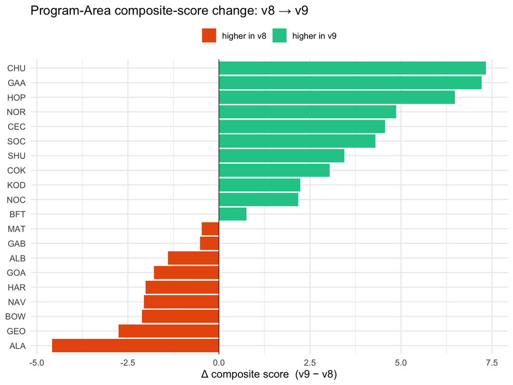

```r
va_col <- glue("score_{va}"); vb_col <- glue("score_{vb}")
d_plot <- d |>
  mutate(programarea_key = factor(programarea_key, levels = programarea_key[order(delta)]),
         sign = ifelse(delta >= 0, glue("higher in {vb}"), glue("higher in {va}")))

ggplot(d_plot, aes(delta, programarea_key, fill = sign)) +
  geom_col() +
  geom_vline(xintercept = 0, linewidth = 0.3) +
  scale_fill_manual(values = setNames(c("#20c997", "#e8590c"),
                                      c(glue("higher in {vb}"), glue("higher in {va}")))) +
  labs(x = glue("Δ composite score  ({vb} − {va})"), y = NULL, fill = NULL,
       title = glue("Program-Area composite-score change: {va} → {vb}")) +
  theme_minimal(base_size = 12) +
  theme(legend.position = "top")
```

```r
d |>
  transmute(`Program Area` = programarea_key,
            !!va := round(.data[[va_col]], 2),
            !!vb := round(.data[[vb_col]], 2),
            `Δ` = round(delta, 2),
            `Δ %` = round(100 * delta / .data[[va_col]], 1)) |>
  knitr::kable(caption = glue("Per-Program-Area composite scores ({va} vs {vb}), sorted by |Δ|"))
```

Per-Program-Area composite scores (v8 vs v9), sorted by |Δ|

| Program Area | v8 | v9 | Δ | Δ % |
| --- | --- | --- | --- | --- |
| CHU | 23.11 | 30.44 | 7.34 | 31.7 |
| GAA | 32.87 | 40.09 | 7.21 | 21.9 |
| HOP | 48.43 | 54.91 | 6.48 | 13.4 |
| NOR | 29.35 | 34.21 | 4.87 | 16.6 |
| ALA | 30.01 | 25.44 | -4.58 | -15.3 |
| CEC | 17.01 | 21.58 | 4.57 | 26.8 |
| SOC | 22.58 | 26.88 | 4.30 | 19.0 |
| SHU | 19.39 | 22.83 | 3.44 | 17.8 |
| COK | 47.93 | 50.96 | 3.04 | 6.3 |
| GEO | 28.94 | 26.18 | -2.76 | -9.5 |
| KOD | 22.19 | 24.42 | 2.23 | 10.0 |
| NOC | 14.33 | 16.51 | 2.18 | 15.2 |
| BOW | 19.08 | 16.96 | -2.11 | -11.1 |
| NAV | 22.60 | 20.55 | -2.06 | -9.1 |
| HAR | 9.28 | 7.27 | -2.01 | -21.7 |
| GOA | 32.08 | 30.29 | -1.79 | -5.6 |
| ALB | 14.94 | 13.54 | -1.40 | -9.4 |
| BFT | 12.38 | 13.13 | 0.75 | 6.1 |
| GAB | 18.14 | 17.62 | -0.51 | -2.8 |
| MAT | 24.85 | 24.38 | -0.47 | -1.9 |

## 3 Per-category breakdown

The same delta, computed for each **species-category** ecoregion-rescaled extinction-risk metric that exists in **both** versions — so a shift in the composite can be attributed to a category (bird, fish, mammal, …) rather than read as one opaque number. Uses the same `msens::score_delta` core per metric.

```r
# metrics shared by both versions, of the per-category ecoregion-rescaled family
metrics_in <- function(con) DBI::dbGetQuery(con, "SELECT metric_key FROM metric")$metric_key
shared <- intersect(metrics_in(con_a), metrics_in(con_b))
cat_metrics <- grep("^extrisk_[a-z_]+_ecoregion_rescaled$", shared, value = TRUE)

# reuse the schema-adaptive core once per metric (handles the v7 `value` / v8 `val` rename)
cat_summary <- purrr::map_dfr(cat_metrics, function(metric) {
  dd <- msens::pra_score_delta(con_a, con_b, metric_key = metric, labels = c(va, vb))
  ss <- msens::score_delta_summary(dd)
  tibble::tibble(
    category = sub("^extrisk_(.*)_ecoregion_rescaled$", "\\1", metric),
    n = ss$n, `mean |Δ|` = round(ss$mean_abs, 3),
    `max |Δ|` = round(ss$max_abs, 3), rmse = round(ss$rmse, 3))
}) |> arrange(desc(`mean |Δ|`))

knitr::kable(cat_summary,
  caption = glue("Per-category ecoregion-rescaled extinction-risk delta, {va} → {vb}"))
```

Per-category ecoregion-rescaled extinction-risk delta, v8 → v9

| category | n | mean \|Δ\| | max \|Δ\| | rmse |
| --- | --- | --- | --- | --- |
| turtle | 11 | 22.816 | 46.976 | 27.520 |
| mammal | 20 | 15.458 | 35.392 | 18.578 |
| fish | 20 | 9.399 | 22.966 | 11.744 |
| invertebrate | 20 | 6.836 | 20.584 | 8.777 |
| coral | 20 | 6.413 | 20.330 | 8.470 |
| bird | 20 | 0.000 | 0.000 | 0.000 |
| primary_producer | 20 | 0.000 | 0.000 | 0.000 |